# Visualizing Image Segmentation using t-SNE

Domagoj Fizulic

April, 2016

# t-SNE

Definition from wikipedia:  
t-distributed stochastic neighbor embedding (t-SNE) is a machine learning algorithm for dimensionality reduction developed by Laurens van der Maaten and Geoffrey Hinton.[1] It is a nonlinear dimensionality reduction technique that is particularly well suited for embedding high-dimensional data into a space of two or three dimensions, which can then be visualized in a scatter plot. Specifically, it models each high-dimensional object by a two- or three-dimensional point in such a way that similar objects are modeled by nearby points and dissimilar objects are modeled by distant points.

The t-SNE algorithm comprises two main stages. First, t-SNE constructs a probability distribution over pairs of high-dimensional objects in such a way that similar objects have a high probability of being picked, whilst dissimilar points have an infinitesimal probability of being picked. Second, t-SNE defines a similar probability distribution over the points in the low-dimensional map, and it minimizes the Kullback–Leibler divergence between the two distributions with respect to the locations of the points in the map. Note that whilst the original algorithm uses the Euclidean distance between objects as the base of its similarity metric, this should be changed as appropriate.

# Data: Image Segmentation Data Set

url: https://archive.ics.uci.edu/ml/datasets/Image+Segmentation

### Data Set Information:

The instances were drawn randomly from a database of 7 outdoor images. The images were handsegmented to create a classification for every pixel.

Each instance is a 3x3 region.

Dataset has 19 features.

# Analysis

Unlike the fixed presentation of PCA, t-SNE can be tuned with several parameters. Below animations show different combinations of number of iterations and number of neighbors.

### 30 neighbors, different iterations

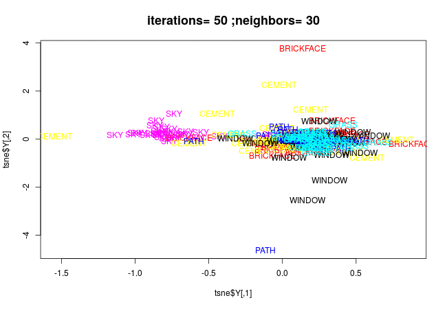

### 1 neighbor, different iterations

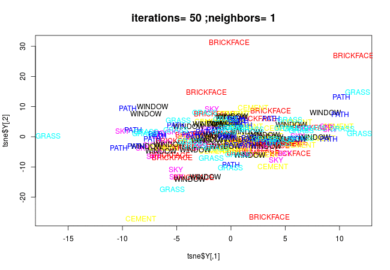

### 500 iterations, different number of neighbors

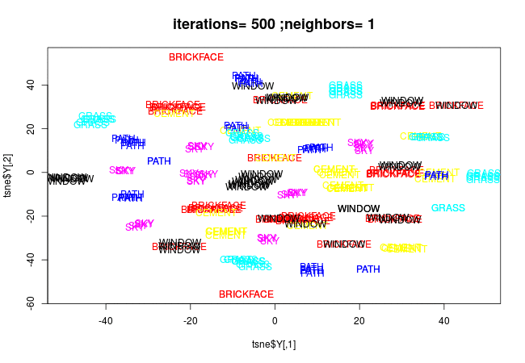

### Findings

Above plots show that this dataset is best separated and classified using one nearest neighbor. Separation and 2D clustering converges around 400 iterations.

# PCA

It is visibile from below plot that a 2D PCA presentaion of this dataset is not as clear and readable as above optimised versions of t-SNE.

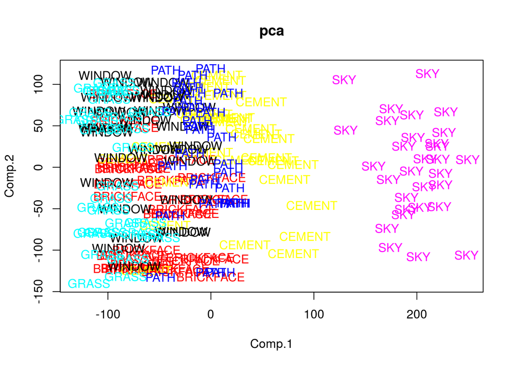